# TBR 2026 — Race Strategy

Published

May 15, 2026

## Current fitness snapshot

| FTP | 237 W (Half Monty ramp test, 2 Apr 2026) |
| --- | --- |
| Last 28-day rides | 21 |
| Last 28-day volume | 36.8 h / 842 km |
| Last 28-day climb | 4975 m |
| Last 28-day TSS proxy | 1887 |
| Long rides ≥3h (90d) | 12 |
| Longest single ride (90d) | 6.9 h / 157 km @ 157 W avg, 171 W NP — 18 Apr |
| Days to start | 14 |

| Date | Ride | Power | % FTP (NP) | HR | Name |
| --- | --- | --- | --- | --- | --- |
| 10 May | 3.5 h / 62 km / 266 m | 151 W avg / 157 W NP | 66% | 110 | Lunch Ride |
| 01 May | 4.4 h / 101 km / 332 m | 166 W avg / 178 W NP | 75% | 124 | Muhu sõõr 2026 |
| 18 Apr | 6.9 h / 157 km / 576 m | 157 W avg / 171 W NP | 72% | 119 | Apr 100+ |
| 11 Apr | 3.8 h / 85 km / 322 m | 145 W avg / 154 W NP | 65% | 111 | Afternoon Ride |
| 10 Apr | 4.2 h / 86 km / 331 m | 124 W avg / 142 W NP | 60% | 105 | Afternoon Ride |
| 03 Apr | 5.0 h / 120 km / 365 m | 150 W avg / 166 W NP | 70% | 114 | Afternoon Ride |
| 29 Mar | 3.6 h / 60 km / 265 m | 150 W avg / 155 W NP | 65% | 112 | Paldiskisse |
| 27 Mar | 3.4 h / 84 km / 264 m | 165 W avg / 177 W NP | 75% | 120 | Afternoon Ride |
| 26 Mar | 4.7 h / 110 km / 349 m | 139 W avg / 145 W NP | 61% | 111 | Afternoon Ride |
| 06 Mar | 3.5 h / 91 km / 1080 m | 132 W avg / 133 W NP | 56% | 113 | Zwift - Wahoo SYSTM: Endurance |
| 24 Feb | 5.9 h / 110 km / 380 m | 142 W avg / 156 W NP | 66% | 117 | 100+ FEB |
| 15 Feb | 3.7 h / 72 km / 257 m | 144 W avg / 152 W NP | 64% | 110 | Afternoon Ride |

**What this changes vs. the original strategy**

The original power targets were anchored on **Hydra Epic 2025** (132W Day 1 → 100-105W by Day 7-8). Two months of additional training has lifted the floor:

Net effect: the day-by-day targets below now sit closer to what your current FTP supports, while preserving the Hydra-derived decay curve for the back half.

## The numbers

| Distance | 1387 km |
| --- | --- |
| Climbing | 24488 m |
| Riding time (model) | 116.9 h |
| Sleep schedule | 02:00-06:30 (4.5h min, 6h max) |
| Estimated finish | Thu 04 Jun 13:30 CEST |
| Target | < 9 days (finish by Sat 6 Jun) |
| FTP | 237 W |

**Model vs reality**

The simulation assumes 100% riding efficiency (no stops). Your Hydra Epic data shows **65-72% efficiency** on multi-day stages (stops for eating, navigation, mechanicals, bathroom). A 19.5h riding window realistically yields **13-14h of pedaling**. The model’s 7-day finish is optimistic; **7.5-8.5 days** is the realistic target at your pace.

## Checkpoint timeline

| Checkpoint | km | Est. arrival | Cutoff | Margin |
| --- | --- | --- | --- | --- |
| CP1 Mazin | 451 | Sun 31 May 09:46 | Mon 01 Jun 17:00 | 31h |
| CP2 Kopilovi | 1060 | Tue 02 Jun 21:26 | Thu 04 Jun 23:59 | 51h |
| Finish Risan | 1395 | Thu 04 Jun 13:30 | Sun 07 Jun 23:59 | 82h |

**Note**

Even with realistic efficiency losses, margins are comfortable. CP1 has **30+ hours** of buffer. The biggest risk is not cutoffs but accumulated fatigue on Days 5-7.

## Day-by-day strategy

### Day 1 — Friday 29 May: Trieste to ~km 179

**Slovenia and Croatian coast → mountains**

| Window | 09:00–00:30 |
| --- | --- |
| Riding (model) | 15.5h |
| Realistic riding | ~11h (first day conservative) |
| Distance | 179 km |
| Climbing | 4000 m |
| Elevation range | 51–1261 m |
| Key terrain | First 50km: 1530m climb. Steep coastal mountains. |

**Strategy:**

- **Resist the start adrenaline.** Day 1 sets the tone for 8 more days. You know this from Hydra E1.
- The opening 50 km is brutal: **1530m of climbing** at 5.9% average grade. This is the Slovenian karst. Don’t try to keep up with anyone.
- **Power cap: 145-155W average** (61-65% FTP). HR stays under 135.
- Anchor: at Hydra E1 you averaged 132W/HR 118 over 25.4h. With a year more training (4.4h Muhu sõõr at 166W/HR 124, May 2026), 145-155W on Day 1 is the right ceiling — fit-but-not-foolish.
- **Nutrition from the first hour**: 60-80g carbs/hr. Don’t wait until hungry.
- First resupply: Kozina (km 17), Slavnik mountain hut (km 28). Stock up in Fužine (km 164, village with shops).
- **Sleep target: Stop by 00:30**, sleep until 06:30 (6h sleep on night 1 is worth it).

**Critical gap: Sveti Pavel → Platak (67 km, 1533m climb, 5.8h)**

No resupply for 67 km through mountain terrain. Carry food and water from Sveti Pavel (km 74).

### Day 2 — Saturday 30 May: ~km 179 to ~km 409

**Croatian highlands — Velebit mountains**

| Window | 06:30–01:59 |
| --- | --- |
| Riding (model) | 19.5h |
| Realistic riding | ~14h |
| Distance | 230 km |
| Climbing | 3800 m |
| Elevation range | 556–1580 m |
| Key terrain | Velebit range. Steep grades (avg 9.2% on climbs). Gravel/forest roads. |

**Strategy:**

**Critical gap: Fužine → Oltari (81 km, 1667m climb, 7.2h)**

Remote mountain section. Carry 3000+ kcal and 2+ liters.

### Day 3 — Sunday 31 May: ~km 409 to ~km 646

**Lika plateau → Dalmatian hinterland**

| Window | 06:30–01:55 |
| --- | --- |
| Riding (model) | 19.4h |
| Realistic riding | ~14h |
| Distance | 237 km |
| Climbing | 3713 m |
| Elevation range | 219–1481 m |
| CP arrival | CP1 Mazin (~km 451) around 09:46 |
| Key terrain | Mix of gravel and paved. Enters Bosnia late in day. |

**Strategy:**

**Critical gap: Knin → Livno (127 km, 2058m climb, 10.5h)**

**The biggest gap on the entire route.** No resupply for 127 km through remote terrain. Load up fully in Knin: 5000+ kcal, 3+ liters. This gap spans from late Day 3 into Day 4.

### Day 4 — Monday 1 June: ~km 646 to ~km 882

**Central Bosnia — mountains and valleys**

| Window | 06:30–01:59 |
| --- | --- |
| Riding (model) | 19.5h |
| Realistic riding | ~14h |
| Distance | 236 km |
| Climbing | 3539 m |
| Elevation range | 53–1509 m |
| Key terrain | Bosnian mountains. Gravel, some paved through towns. Mostar at km 812. |

**Strategy:**

- This is the **mental halfway point**. 4 days done, 4 to go. Expect a psychological dip.
- Mostar (km 812) is the biggest city since Trieste — **major resupply opportunity**. Get a proper meal, fill everything.
- Power target: 115-125W. Accept it. Hydra showed you drop 20% by mid-race.
- **Watch for appetite crash** around Day 3-4. Force yourself to eat even if food sounds terrible. Switch to savory/salty foods if sweet becomes unbearable.

**Mostar (km 812)**

Real city. Restaurants, shops, pharmacies. If you need bike parts, this is the place. Consider a 30-45min longer stop for a hot meal and mental reset.

### Day 5 — Tuesday 2 June: ~km 882 to ~km 1091

**Eastern Bosnia — the hard middle**

[output not shown]

**Strategy:**

- **4102m of climbing** — second hardest day. The section km 900-950 (after Ulog) is particularly steep.
- Approaching CP2 Kopilovi (km 1060). Arrival estimated around evening.
- **This is the day that breaks people.** Fatigue is maximal, terrain is hard, remoteness is real.
- Keep the routine. Wake, eat, ride, eat, ride, eat, sleep. Nothing else matters.
- Watch for the fountain at km 938 — it may be the only water for a long stretch.

**Critical gap: Ulog → Fountain (41 km, 1116m climb, 3.9h)**

Followed by Fountain → Miljevina (52 km, 747m climb, 4.2h). Remote Bosnian mountains. Carry extra water.

### Day 6 — Wednesday 3 June: ~km 1091 to ~km 1290

**Montenegro mountains — the hardest day**

| Window | 06:30–00:30 |
| --- | --- |
| Riding (model) | 18.0h |
| Realistic riding | ~13h |
| Distance | 200 km |
| Climbing | 4619 m |
| Elevation range | 957–1880 m |
| CP arrival | CP2 Kopilovi (~km 1060) early if not reached Day 5 |
| Key terrain | HARDEST DAY. 4619m climbing. Durmitor and Montenegro mountains. Avg 9.9% on climbs. |

**Strategy:**

**Critical gap: CP2 Kopilovi → Žabljak (100 km, 2335m climb, 8.9h)**

And Kolašin → Nikšić (97 km, 1963m climb, 8.5h). Both are massive gaps in Montenegro mountains.

### Day 7 — Thursday 4 June: ~km 1290 to Finish (km 1395)

**The final 97 km — descent to Risan**

| Window | 06:30–13:30 |
| --- | --- |
| Riding (model) | 7.0h |
| Distance | 97 km |
| Climbing | 715 m |
| Elevation range | 36–1505 m |
| Key terrain | Only 715m climbing. Mostly descent from mountains to Kotor Bay (sea level). |

**Strategy:**

- **The easy day.** Only 97 km and 715m of climbing. Mostly downhill to Kotor Bay.
- Don’t crash on the descents. Tired riders crash. **Brake before corners**, not in them.
- Nikšić (km 1325) is the last city before the finish — last resupply if needed.
- **Enjoy the final descent to Risan.** You’ve earned it.

**Tip**

Model estimates arrival around **13:30 on Thu 4 June** — 6.2 days. With realistic efficiency, expect **finish Fri 5 Jun or Sat 6 Jun**, well within your 9-day target and days before the cutoff.

## Power strategy

[output not shown]

### Power decay over multi-day

Your Hydra Epic data shows a clear power decay pattern:

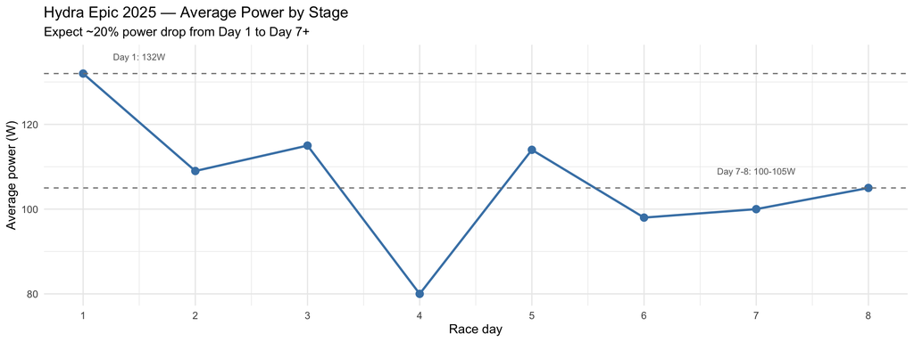

**Implications for TBR (revised May 2026 with current fitness):**

- Day 1: **~145-155W avg** — fitter base + adrenaline, but still capped to protect Days 4-7
- Days 2-3: ~130-145W avg → settling in, hardest climbing days
- Days 4-5: ~115-130W avg → fatigue accumulating, eat through it
- Days 6-7: ~105-115W avg → deep fatigue, this is expected
- **Don’t fight the decay.** It’s physiology. Maintain *effort*, accept lower *power*. The 20% Hydra decay still applies — the curve just shifts up because the starting point is higher.

## Nutrition plan

### Hourly targets

| Riding | Carbs/hr | Fluid/hr | What to eat |
| --- | --- | --- | --- |
| Hours 1-4 | 80g | 500-750ml | Gels, bars — whatever is convenient |
| Hours 5-10 | 70-80g | 500-750ml | Mix gels/bars with real food (sandwich, banana) |
| Hours 10-14 | 60-70g | 500ml | Savory foods, rice, bread — sweet becomes repulsive |
| At stops | Eat a full meal if >15min stop | Drink to thirst | Whatever hot food is available. Soup, pasta, pizza. |

### Daily nutrition targets

| Metric | Target | Notes |
| --- | --- | --- |
| Total kcal intake | 6000-8000 | You’ll burn 8000-10000, but gut limits absorption |
| Carbohydrates | 500-700g | Main fuel source |
| Protein | 100-150g | From real food at resupply stops |
| Sodium | 2000-3000mg | More in heat; salt tablets or electrolyte mix |
| Caffeine | Reserve for nights | Cola at gas stations, caffeine gels after midnight |

### Resupply strategy

| Location | km | +km | Type | Day | Est. arrival |
| --- | --- | --- | --- | --- | --- |
| Kozina (SLO) | 17 | 17 | Village | 1 | Fri 29 May 10:31 |
| Slavnik (SLO) | 28 | 12 | Mountain hut | 1 | Fri 29 May 11:49 |
| Dane (CRO) | 47 | 19 | Fountain | 1 | Fri 29 May 13:25 |
| Sveti Pavel (SLO) | 74 | 27 | Fountain | 1 | Fri 29 May 15:35 |
| Platak (CRO) | 141 | 67 | Mountain hut | 1 | Fri 29 May 21:23 |
| Fužine (CRO) | 164 | 23 | Village | 1 | Fri 29 May 23:02 |
| Oltari (CRO) | 245 | 81 | Fountain | 2 | Sat 30 May 12:14 |
| Dom Zavižan (CRO) | 260 | 15 | Mountain hut | 2 | Sat 30 May 14:03 |
| Gospić (CRO) | 345 | 85 | City | 2 | Sat 30 May 20:30 |
| CP1 Mazin (CRO) | 451 | 106 | Checkpoint | 3 | Sun 31 May 09:46 |
| Velika Popina (CRO) | 490 | 39 | Fountain | 3 | Sun 31 May 12:55 |
| Knin (CRO) | 537 | 47 | City | 3 | Sun 31 May 16:38 |
| Livno (BiH) | 664 | 127 | Village | 4 | Mon 01 Jun 07:48 |
| Šuica (BiH) | 701 | 37 | Village | 4 | Mon 01 Jun 11:19 |
| Mostar (BiH) | 812 | 111 | City | 4 | Mon 01 Jun 19:42 |
| Nevesinje (BiH) * | 858 | 46 | Village | 4 | Mon 01 Jun 23:58 |
| Ulog (BiH) | 897 | 39 | Village | 5 | Tue 02 Jun 07:39 |
| Fountain (BiH) | 938 | 41 | Fountain | 5 | Tue 02 Jun 11:33 |
| Miljevina (BiH) * | 990 | 52 | Village | 5 | Tue 02 Jun 15:43 |
| Popov Most (BiH) | 1034 | 44 | Village | 5 | Tue 02 Jun 19:35 |
| Brod (BiH) | 1055 | 21 | Village | 5 | Tue 02 Jun 21:02 |
| CP2 Kopilovi (BiH) | 1060 | 5 | Checkpoint | 5 | Tue 02 Jun 21:26 |
| Žabljak (MNE) | 1160 | 100 | City | 6 | Wed 03 Jun 12:21 |
| Njegovuđa (MNE) | 1170 | 10 | Village | 6 | Wed 03 Jun 13:14 |
| Kolašin (MNE) * | 1228 | 58 | City | 6 | Wed 03 Jun 18:24 |
| Nikšić (MNE) | 1325 | 97 | City | 7 | Thu 04 Jun 08:52 |
| Risan / Finish | 1395 | 70 | Finish | 8 | Thu 04 Jun 13:30 |

`*` = off-route

| From → To | Gap km | Climb | Riding hours | Day |
| --- | --- | --- | --- | --- |
| Livno (BiH) | 127 | 2058m | 10.6h | 4 |
| Mostar (BiH) | 111 | 1035m | 8.4h | 4 |
| CP1 Mazin (CRO) | 106 | 1720m | 8.8h | 3 |
| Žabljak (MNE) | 100 | 2335m | 8.9h | 6 |
| Nikšić (MNE) | 97 | 1963m | 8.5h | 7 |
| Gospić (CRO) | 85 | 720m | 6.4h | 2 |
| Oltari (CRO) | 81 | 1667m | 7.2h | 2 |
| Risan / Finish | 70 | 616m | 4.6h | 8 |
| Platak (CRO) | 67 | 1533m | 5.8h | 1 |

**The 3 biggest gaps**

1. **Knin → Livno (127 km)**: Fill everything in Knin. Carry 5000+ kcal, 3L water.
2. **Šuica → Mostar (111 km)**: Stock up in Šuica.
3. **Gospić → CP1 Mazin (106 km)**: Last big resupply in Gospić (city with shops).

## Sleep strategy

### Schedule

|  | Target | Notes |
| --- | --- | --- |
| **Stop riding** | 00:30-02:00 | Hard stop. No riding after 02:00. |
| **Sleep** | 02:00-06:30 (4.5h) | Minimum. Take 6h on Night 1 and after hardest days. |
| **Wake** | 06:30 | Same time every day. Routine = survival. |
| **Rolling** | By 07:00 | 30min for wake-up, eat, pack, bathroom |

### Sleep execution

1. **Scout bivvy spot 15-20 min before stopping.** Don’t ride until 02:00 then spend 30min looking.
2. Target: **15 min from stopping to sleeping.** Practice this before the race.
3. Setup: bivvy bag/tent → sleeping bag → earplugs → eye mask → alarm set → sleep.
4. **Don’t skip sleep to make time.** Sleep deprivation costs more than it saves after Day 3.

### Night riding

- After Day 2, you’ll be riding in darkness from ~21:00-00:30 every night.
- **Lights**: Helmet + bar mount. Spare batteries. USB charging from dynamo or power bank.
- **Navigation**: GPS visibility is critical at night. Mount at eye level.
- **Drowsiness**: If you nod off on the bike, stop immediately. 15-20min “power nap” is better than crashing.

## Efficiency analysis

Your Hydra Epic efficiency data:

| Stage | Moving (h) | Elapsed (h) | Stops (h) | Efficiency (%) |
| --- | --- | --- | --- | --- |
| E1 | 25.4 | 37.8 | 12.4 | 67.2 |
| E2 | 14.1 | 20.3 | 6.2 | 69.5 |
| E3 | 12.1 | 17.1 | 5.0 | 70.8 |
| E4 | 12.5 | 17.4 | 4.9 | 71.8 |
| E5 | 12.9 | 18.2 | 5.3 | 70.9 |
| E6 | 11.7 | 18.1 | 6.4 | 64.6 |
| E7 | 11.5 | 16.9 | 5.4 | 68.0 |
| E8 | 23.1 | 37.1 | 14.0 | 62.3 |

**Key insight:** You spend **5-6 hours per day NOT riding** (eating, navigation, mechanicals, bathroom, transitions). For TBR planning:

- **19.5h available window** (06:30-02:00) × 70% efficiency = **~13.5h actual riding**
- At your speed model, that’s **140-170 km/day** — right on target for sub-9-day finish
- To improve: reduce stop time (eat on the bike, fast bivvy setup, less dithering at junctions)

## Equipment checklist

### Critical (race-ending if missing)

| Category | Items |
| --- | --- |
| **Navigation** | GPS with full TBR route loaded, backup phone with offline maps, USB charger |
| **Lights** | Helmet light + bar light, spare batteries, USB charging cable |
| **Repair** | Spare tube ×2, patch kit, tire boot, multi-tool, chain quick link, tire lever |
| **Sleep** | Bivvy bag or ultralight tent, sleeping bag/quilt (comfort 5-10°C), inflatable pillow |
| **Safety** | Emergency bivvy (reflective), phone with local emergency numbers, ID + insurance card |

### Important (race-impacting if missing)

| Category | Items |
| --- | --- |
| **Clothing** | Rain jacket (waterproof), arm warmers, leg warmers, wind vest, spare chamois |
| **Nutrition** | Frame bag for food, 2+ bottle cages, electrolyte mix, caffeine gels for night |
| **Comfort** | Chamois cream, anti-chafing, lip balm with SPF, sunscreen |
| **Electronics** | Power bank (10000+ mAh), charging cables, earplugs, eye mask |

### Weather expectations (late May — early June, Balkans)

| Elevation | Day temp | Night temp | Rain risk | Notes |
| --- | --- | --- | --- | --- |
| < 500m | 20-30°C | 12-18°C | Moderate | Can be hot in valleys |
| 500-1000m | 15-25°C | 8-14°C | Moderate |  |
| 1000-1500m | 10-20°C | 4-10°C | High | Mountain weather changes fast |
| > 1500m | 5-15°C | 0-6°C | High | Possible frost above 1800m |

## Mental strategy

### The five phases of ultra-racing

| Phase | When | What happens | What to do |
| --- | --- | --- | --- |
| **Euphoria** | Day 1 | Everything feels great, adrenaline high | Rein it in. You know the cost of going too hard on Day 1. |
| **Settling** | Days 2-3 | Finding rhythm, body adjusting | Establish routine. Eat, ride, sleep on schedule. |
| **The Pit** | Days 4-5 | Fatigue peaks, motivation drops, body hurts everywhere | **Keep riding.** This passes. Eat something warm. Call home. Small goals (next resupply). |
| **Acceptance** | Days 6-7 | Pain becomes background noise, robot mode | Autopilot is OK. Just keep the routine going. |
| **Finish smell** | Day 7+ | Energy returns, excitement builds | Don’t take risks. No heroic descents. The finish is coming. |

### Decision rules

Pre-make these decisions so you don’t have to think when exhausted:

1. **“Should I keep riding?”** → If it’s before 00:30: yes. If after 02:00: stop immediately.
2. **“Should I eat?”** → Yes. Always yes. Even if not hungry.
3. **“Should I skip sleep?”** → No. Never after Day 2.
4. **“Should I push harder?”** → No. Not until Day 7 and the finish is within reach.
5. **“Should I quit?”** → Sleep on it. Literally. If you still want to quit after sleeping, re-evaluate. Most “I want to quit” feelings pass with food + sleep.

### Mantras

- *“I’ve done this before.”* (You have. Hydra was 8 days.)
- *“Just ride to the next resupply.”* (Never think about the finish. Think about the next 50 km.)
- *“Eat. Drink. Pedal. Repeat.”*

## Hardest sections — know what’s coming

| Section | Climb | Avg speed | Time | Day |
| --- | --- | --- | --- | --- |
| km 1225–1275 | 1624m | 10.0 km/h | 5.0h | 6 |
| km 1075–1125 | 1590m | 10.2 km/h | 4.9h | 5 |
| km 0–50 | 1530m | 10.7 km/h | 4.7h | 1 |
| km 1200–1250 | 1387m | 10.5 km/h | 4.8h | 6 |
| km 900–950 | 1349m | 10.6 km/h | 4.7h | 5 |
| km 1050–1100 | 1296m | 10.7 km/h | 4.7h | 5 |
| km 225–275 | 1281m | 10.4 km/h | 4.8h | 2 |
| km 575–625 | 1221m | 11.1 km/h | 4.5h | 3 |
| km 200–250 | 1201m | 10.5 km/h | 4.8h | 2 |
| km 25–75 | 1192m | 11.6 km/h | 4.3h | 1 |

## Summary: the plan in one page

**Race in 7 words**

**Start slow. Eat always. Sleep enough. Finish.**

| Day | Date | Target km | Climbing | Key waypoints | Stop |
| --- | --- | --- | --- | --- | --- |
| 1 | Fri 29 May | ~179 | 4000m | Fužine (km 164) | 00:30, sleep 6h |
| 2 | Sat 30 May | ~230 | 3800m | Gospić (km 345) | 02:00, sleep 4.5h |
| 3 | Sun 31 May | ~237 | 3713m | **CP1 Mazin** (km 451), Knin (km 537) | 02:00, sleep 4.5h |
| 4 | Mon 1 Jun | ~236 | 3539m | Livno (km 664), **Mostar** (km 812) | 02:00, sleep 4.5h |
| 5 | Tue 2 Jun | ~209 | 4102m | CP2 approach, remote Bosnia | 00:30, sleep 6h |
| 6 | Wed 3 Jun | ~200 | **4619m** | **CP2 Kopilovi**, Žabljak (km 1160) | 00:30, sleep 6h |
| 7 | Thu 4 Jun | ~97 | 715m | Nikšić → **Risan FINISH** | **Done** |

**Realistic finish: Friday 5 June or Saturday 6 June** — well within the 9-day target.

*Generated 2026-05-15 using GPX route analysis, Strava training data (FTP 237W), and Hydra Epic 2025 race data.*